# Project Name: `Student insomnia and educational outcomes`

### Project team members:

- `Yogev Shabtay`
- `Tomer Stupko`
- `Sagi Fish`

### Project number: 5

[figure not shown]

### Project description:

`בפרוייקט זה נבחן את הקשר בין שעות השינה הממוצעות של סטודנטים ואיכות השינה שלהם לבין הביצועים האקדמיים שלהם. בנוסף, נבדוק את הקשר בין הרגלים שונים לבין איכות השינה. המטרה שלנו היא לבדוק איך ניתן לשפר את איכות השינה במטרה לשפר הישגים אקדמיים.`

### Link to the data:

https://data.mendeley.com/datasets/5mvrx4v62z/2

### Explaining of the data source:

`The data was collected through an online survey administered via Google Forms in Oct-Nov 2024. Respondents were asked to provide insights into their sleep behaviors and the effects on their academic and daily activities.`

### התרומה של כל חבר צוות לפרויקט:

את הפרויקט התחלנו 2 ושגיא הצטרף לאחר שמצאנו דאטה והתחלנו לחקור עליו. עבדנו על הפרויקט ביחד ומצאנו מסקנות בעזרת עבודה משותפת.

```python
import pandas as pd
import numpy as np
import matplotlib.pyplot as plt
import seaborn as sns
df = pd.read_csv("https://raw.githubusercontent.com/TomerStupko/data-analysis-project/refs/heads/main/Student%20Insomnia%20and%20Educational%20Outcomes%20Dataset_version-2.csv")
df
```

|  | Timestamp | 1. What is your year of study? | 2. What is your gender? | 3. How often do you have difficulty falling asleep at night? | 4. On average, how many hours of sleep do you get on a typical day? | 5. How often do you wake up during the night and have trouble falling back asleep? | 6. How would you rate the overall quality of your sleep? | 7. How often do you experience difficulty concentrating during lectures or studying due to lack of sleep? | 8. How often do you feel fatigued during the day, affecting your ability to study or attend classes? | 9. How often do you miss or skip classes due to sleep-related issues (e.g., insomnia, feeling tired)? | 10. How would you describe the impact of insufficient sleep on your ability to complete assignments and meet deadlines? | 11. How often do you use electronic devices (e.g., phone, computer) before going to sleep? | 12. How often do you consume caffeine (coffee, energy drinks) to stay awake or alert? | 13. How often do you engage in physical activity or exercise? | 14. How would you describe your stress levels related to academic workload? | 15. How would you rate your overall academic performance (GPA or grades) in the past semester? |
| --- | --- | --- | --- | --- | --- | --- | --- | --- | --- | --- | --- | --- | --- | --- | --- | --- |
| 0 | 10/24/2024 16:51:15 | Graduate student | Male | Often (5-6 times a week) | 7-8 hours | Often (5-6 times a week) | Good | Sometimes | Often | Often (3-4 times a week) | Moderate impact | Often (5-6 times a week) | Rarely (1-2 times a week) | Sometimes (3-4 times a week) | High stress | Average |
| 1 | 10/24/2024 16:51:51 | Third year | Male | Often (5-6 times a week) | 7-8 hours | Often (5-6 times a week) | Good | Often | Sometimes | Sometimes (1-2 times a week) | Major impact | Sometimes (3-4 times a week) | Sometimes (3-4 times a week) | Sometimes (3-4 times a week) | Low stress | Good |
| 2 | 10/24/2024 16:52:21 | First year | Female | Sometimes (3-4 times a week) | 7-8 hours | Sometimes (3-4 times a week) | Good | Often | Often | Sometimes (1-2 times a week) | Major impact | Often (5-6 times a week) | Often (5-6 times a week) | Often (5-6 times a week) | High stress | Below Average |
| 3 | 10/24/2024 16:53:00 | Third year | Male | Often (5-6 times a week) | More than 8 hours | Sometimes (3-4 times a week) | Poor | Often | Often | Rarely (1-2 times a month) | Minor impact | Sometimes (3-4 times a week) | Sometimes (3-4 times a week) | Every day | Extremely high stress | Excellent |
| 4 | 10/24/2024 16:53:25 | Graduate student | Male | Often (5-6 times a week) | 7-8 hours | Often (5-6 times a week) | Very good | Always | Sometimes | Sometimes (1-2 times a week) | Moderate impact | Sometimes (3-4 times a week) | Sometimes (3-4 times a week) | Often (5-6 times a week) | Low stress | Average |
| ... | ... | ... | ... | ... | ... | ... | ... | ... | ... | ... | ... | ... | ... | ... | ... | ... |
| 991 | 12/15/2024 6:08:02 | Graduate student | Female | Often (5-6 times a week) | More than 8 hours | Every night | Very good | Often | Always | Sometimes (1-2 times a week) | Severe impact | Every night | Every day | Often (5-6 times a week) | Extremely high stress | Average |
| 992 | 12/15/2024 6:08:09 | Graduate student | Female | Rarely (1-2 times a week) | 6-7 hours | Sometimes (3-4 times a week) | Average | Rarely | Rarely | Sometimes (1-2 times a week) | Major impact | Often (5-6 times a week) | Never | Rarely (1-2 times a week) | Low stress | Good |
| 993 | 12/15/2024 6:08:30 | Third year | Female | Never | More than 8 hours | Sometimes (3-4 times a week) | Average | Rarely | Rarely | Rarely (1-2 times a month) | No impact | Never | Often (5-6 times a week) | Rarely (1-2 times a week) | High stress | Average |
| 994 | 12/15/2024 6:08:31 | Third year | Male | Sometimes (3-4 times a week) | Less than 4 hours | Never | Average | Never | Rarely | Often (3-4 times a week) | Major impact | Sometimes (3-4 times a week) | Rarely (1-2 times a week) | Every day | Extremely high stress | Excellent |
| 995 | 12/15/2024 11:49:05 | Third year | Female | Often (5-6 times a week) | More than 8 hours | Often (5-6 times a week) | Good | Rarely | Sometimes | Always | Major impact | Sometimes (3-4 times a week) | Sometimes (3-4 times a week) | Every day | Extremely high stress | Good |

996 rows × 16 columns

```python
df.shape
```

```
(996, 16)
```

#### Write three questions you would like to answer using this data

1. `?האם קיים קשר בין שעות שינה ממוצעות לבין הישגים אקדמיים`
2. `?כיצד שימוש במסכים לפני השינה משפיע על איכות השינה`
3. `?האם חוסר בשעות שינה מגביר את הלחץ בלימודים`

```python
df.columns
```

```
Index(['Timestamp', '1. What is your year of study?',
       '2. What is your gender?',
       '3. How often do you have difficulty falling asleep at night? ',
       '4. On average, how many hours of sleep do you get on a typical day?',
       '5. How often do you wake up during the night and have trouble falling back asleep?',
       '6. How would you rate the overall quality of your sleep?',
       '7. How often do you experience difficulty concentrating during lectures or studying due to lack of sleep?',
       '8. How often do you feel fatigued during the day, affecting your ability to study or attend classes?',
       '9. How often do you miss or skip classes due to sleep-related issues (e.g., insomnia, feeling tired)?',
       '10. How would you describe the impact of insufficient sleep on your ability to complete assignments and meet deadlines?',
       '11. How often do you use electronic devices (e.g., phone, computer) before going to sleep?',
       '12. How often do you consume caffeine (coffee, energy drinks) to stay awake or alert?',
       '13. How often do you engage in physical activity or exercise?',
       '14. How would you describe your stress levels related to academic workload?',
       '15. How would you rate your overall academic performance (GPA or grades) in the past semester?'],
      dtype='object')
```

```python
df = df.rename(columns={'1. What is your year of study?':'year of study','2. What is your gender?':'gender','3. How often do you have difficulty falling asleep at night? ':'difficulty falling asleep','4. On average, how many hours of sleep do you get on a typical day?':'sleep hours','5. How often do you wake up during the night and have trouble falling back asleep?':'wake up at night','6. How would you rate the overall quality of your sleep?':'sleep quality','7. How often do you experience difficulty concentrating during lectures or studying due to lack of sleep?':'difficulty concentrating','8. How often do you feel fatigued during the day, affecting your ability to study or attend classes?':'fatigued during the day','9. How often do you miss or skip classes due to sleep-related issues (e.g., insomnia, feeling tired)?':'skip class','10. How would you describe the impact of insufficient sleep on your ability to complete assignments and meet deadlines?':'impact on ability to complete assignments','11. How often do you use electronic devices (e.g., phone, computer) before going to sleep?':'screen time before bed','12. How often do you consume caffeine (coffee, energy drinks) to stay awake or alert?':'caffeine consumption','13. How often do you engage in physical activity or exercise?':'physical activity','14. How would you describe your stress levels related to academic workload?':'academic stress level','15. How would you rate your overall academic performance (GPA or grades) in the past semester?':'academic performance'})
df.columns
```

```
Index(['Timestamp', 'year of study', 'gender', 'difficulty falling asleep',
       'sleep hours', 'wake up at night', 'sleep quality',
       'difficulty concentrating', 'fatigued during the day', 'skip class',
       'impact on ability to complete assignments', 'screen time before bed',
       'caffeine consumption', 'physical activity', 'academic stress level',
       'academic performance'],
      dtype='object')
```

```python
df.head()
```

|  | Timestamp | year of study | gender | difficulty falling asleep | sleep hours | wake up at night | sleep quality | difficulty concentrating | fatigued during the day | skip class | impact on ability to complete assignments | screen time before bed | caffeine consumption | physical activity | academic stress level | academic performance |
| --- | --- | --- | --- | --- | --- | --- | --- | --- | --- | --- | --- | --- | --- | --- | --- | --- |
| 0 | 10/24/2024 16:51:15 | Graduate student | Male | Often (5-6 times a week) | 7-8 hours | Often (5-6 times a week) | Good | Sometimes | Often | Often (3-4 times a week) | Moderate impact | Often (5-6 times a week) | Rarely (1-2 times a week) | Sometimes (3-4 times a week) | High stress | Average |
| 1 | 10/24/2024 16:51:51 | Third year | Male | Often (5-6 times a week) | 7-8 hours | Often (5-6 times a week) | Good | Often | Sometimes | Sometimes (1-2 times a week) | Major impact | Sometimes (3-4 times a week) | Sometimes (3-4 times a week) | Sometimes (3-4 times a week) | Low stress | Good |
| 2 | 10/24/2024 16:52:21 | First year | Female | Sometimes (3-4 times a week) | 7-8 hours | Sometimes (3-4 times a week) | Good | Often | Often | Sometimes (1-2 times a week) | Major impact | Often (5-6 times a week) | Often (5-6 times a week) | Often (5-6 times a week) | High stress | Below Average |
| 3 | 10/24/2024 16:53:00 | Third year | Male | Often (5-6 times a week) | More than 8 hours | Sometimes (3-4 times a week) | Poor | Often | Often | Rarely (1-2 times a month) | Minor impact | Sometimes (3-4 times a week) | Sometimes (3-4 times a week) | Every day | Extremely high stress | Excellent |
| 4 | 10/24/2024 16:53:25 | Graduate student | Male | Often (5-6 times a week) | 7-8 hours | Often (5-6 times a week) | Very good | Always | Sometimes | Sometimes (1-2 times a week) | Moderate impact | Sometimes (3-4 times a week) | Sometimes (3-4 times a week) | Often (5-6 times a week) | Low stress | Average |

```python
df['year of study_encoded'] = df['year of study'].map({
    'First year': 1,
    'Second year': 2,
    'Third year': 3,
    'Graduate student': 4,
})
df['difficulty falling asleep_encoded'] = df['difficulty falling asleep'].map({
    'Never': 0,
    'Rarely (1-2 times a week)': 1,
    'Sometimes (3-4 times a week)': 2,
    'Often (5-6 times a week)': 3,
    'Every night': 4
})

df['sleep hours_encoded'] = df['sleep hours'].map({
    'Less than 4 hours': 0,
    '4-5 hours': 1,
    '6-7 hours': 2,
    '7-8 hours': 3,
    'More than 8 hours': 4
})

df['wake up at night_encoded'] = df['wake up at night'].map({
    'Never': 0,
    'Rarely (1-2 times a week)': 1,
    'Sometimes (3-4 times a week)': 2,
    'Often (5-6 times a week)': 3,
    'Every night': 4
})

df['sleep quality_encoded'] = df['sleep quality'].map({
    'Very poor': 0,
    'Poor': 1,
    'Average': 2,
    'Good': 3,
    'Very good': 4
})

df['difficulty concentrating_encoded'] = df['difficulty concentrating'].map({
    'Never': 0,
    'Rarely': 1,
    'Sometimes': 2,
    'Often': 3,
    'Always': 4
})

df['fatigued during the day_encoded'] = df['fatigued during the day'].map({
    'Never': 0,
    'Rarely': 1,
    'Sometimes': 2,
    'Often': 3,
    'Always': 4
})

df['skip class_encoded'] = df['skip class'].map({
    'Never': 0,
    'Rarely (1-2 times a month)': 1,
    'Sometimes (1-2 times a week)': 2,
    'Often (3-4 times a week)': 3,
    'Always': 4
})

df['impact on ability to complete assignments_encoded'] = df['impact on ability to complete assignments'].map({
    'No impact': 0,
    'Minor impact': 1,
    'Moderate impact': 2,
    'Major impact': 3,
    'Severe impact': 4
})

df['screen time before bed_encoded'] = df['screen time before bed'].map({
    'Never': 0,
    'Rarely (1-2 times a week)': 1,
    'Sometimes (3-4 times a week)': 2,
    'Often (5-6 times a week)': 3,
    'Every night': 4
})

df['caffeine consumption_encoded'] = df['caffeine consumption'].map({
    'Never': 0,
    'Rarely (1-2 times a week)': 1,
    'Sometimes (3-4 times a week)': 2,
    'Often (5-6 times a week)': 3,
    'Every day': 4
})

df['physical activity_encoded'] = df['physical activity'].map({
    'Never': 0,
    'Rarely (1-2 times a week)': 1,
    'Sometimes (3-4 times a week)': 2,
    'Often (5-6 times a week)': 3,
    'Every day': 4
})

df['academic stress level_encoded'] = df['academic stress level'].map({
    'No stress': 0,
    'Low stress': 1,
    'High stress': 2,
    'Extremely high stress': 3
})

df['academic performance_encoded'] = df['academic performance'].map({
    'Poor': 0,
    'Below Average': 1,
    'Average': 2,
    'Good': 3,
    'Excellent': 4
})

df.head()
```

|  | Timestamp | year of study | gender | difficulty falling asleep | sleep hours | wake up at night | sleep quality | difficulty concentrating | fatigued during the day | skip class | ... | sleep quality_encoded | difficulty concentrating_encoded | fatigued during the day_encoded | skip class_encoded | impact on ability to complete assignments_encoded | screen time before bed_encoded | caffeine consumption_encoded | physical activity_encoded | academic stress level_encoded | academic performance_encoded |
| --- | --- | --- | --- | --- | --- | --- | --- | --- | --- | --- | --- | --- | --- | --- | --- | --- | --- | --- | --- | --- | --- |
| 0 | 10/24/2024 16:51:15 | Graduate student | Male | Often (5-6 times a week) | 7-8 hours | Often (5-6 times a week) | Good | Sometimes | Often | Often (3-4 times a week) | ... | 3 | 2 | 3 | 3 | 2 | 3 | 1 | 2 | 2 | 2 |
| 1 | 10/24/2024 16:51:51 | Third year | Male | Often (5-6 times a week) | 7-8 hours | Often (5-6 times a week) | Good | Often | Sometimes | Sometimes (1-2 times a week) | ... | 3 | 3 | 2 | 2 | 3 | 2 | 2 | 2 | 1 | 3 |
| 2 | 10/24/2024 16:52:21 | First year | Female | Sometimes (3-4 times a week) | 7-8 hours | Sometimes (3-4 times a week) | Good | Often | Often | Sometimes (1-2 times a week) | ... | 3 | 3 | 3 | 2 | 3 | 3 | 3 | 3 | 2 | 1 |
| 3 | 10/24/2024 16:53:00 | Third year | Male | Often (5-6 times a week) | More than 8 hours | Sometimes (3-4 times a week) | Poor | Often | Often | Rarely (1-2 times a month) | ... | 1 | 3 | 3 | 1 | 1 | 2 | 2 | 4 | 3 | 4 |
| 4 | 10/24/2024 16:53:25 | Graduate student | Male | Often (5-6 times a week) | 7-8 hours | Often (5-6 times a week) | Very good | Always | Sometimes | Sometimes (1-2 times a week) | ... | 4 | 4 | 2 | 2 | 2 | 2 | 2 | 3 | 1 | 2 |

5 rows × 30 columns

```python
df.isnull().sum()
```

```
Timestamp                                            0
year of study                                        0
gender                                               0
difficulty falling asleep                            0
sleep hours                                          0
wake up at night                                     0
sleep quality                                        0
difficulty concentrating                             0
fatigued during the day                              0
skip class                                           0
impact on ability to complete assignments            0
screen time before bed                               0
caffeine consumption                                 0
physical activity                                    0
academic stress level                                0
academic performance                                 0
year of study_encoded                                0
difficulty falling asleep_encoded                    0
sleep hours_encoded                                  0
wake up at night_encoded                             0
sleep quality_encoded                                0
difficulty concentrating_encoded                     0
fatigued during the day_encoded                      0
skip class_encoded                                   0
impact on ability to complete assignments_encoded    0
screen time before bed_encoded                       0
caffeine consumption_encoded                         0
physical activity_encoded                            0
academic stress level_encoded                        0
academic performance_encoded                         0
dtype: int64
```

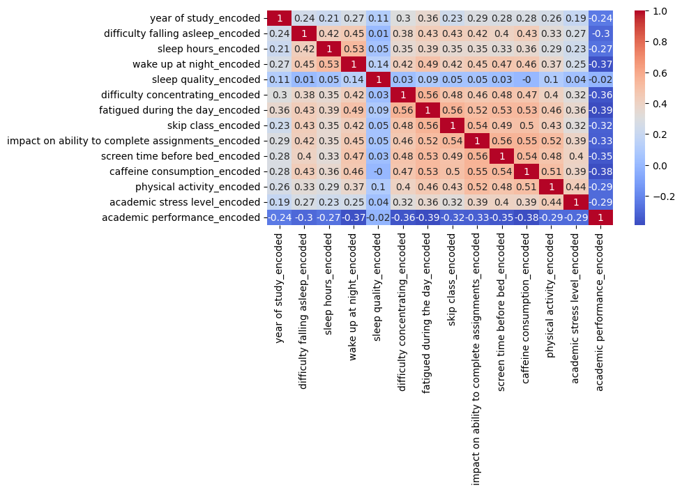

```python
plt.figure(figsize=(8,4))
correlation_matrix = df.corr(numeric_only = True,method = 'pearson').round(2)
sns.heatmap(data=correlation_matrix,cmap='coolwarm', annot=True)
```

## We'll take a closer look at the connection between caffeine consumption and fatigue.

[figure not shown]

### We created a graph that shows the distribution of different levels of fatigue across various caffeine consumption levels.

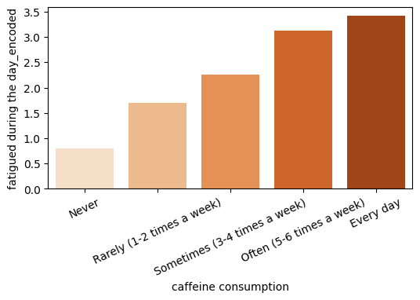

```python
plt.figure(figsize=(6, 3))
order = ['Never','Rarely (1-2 times a week)','Sometimes (3-4 times a week)','Often (5-6 times a week)','Every day']
colors = sns.color_palette("Oranges", n_colors=5)
color_dict = dict(zip(order, colors))
sns.barplot(data = df,x = 'caffeine consumption',hue = 'caffeine consumption',order=order, y = 'fatigued during the day_encoded',errorbar = None,palette=color_dict,legend=False)
plt.xticks(rotation = 25)
plt.show()
```

### 📊

*As the graph shows, those who reported they consume more caffeine, also reported that they feel more fatigue.*

#### We wanted to see if the conclusion still holds when considering only those whose sleep quality was good.

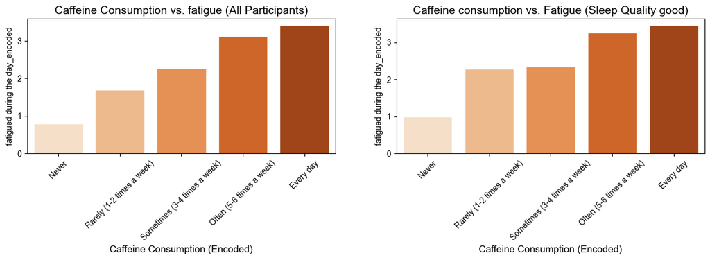

```python
fig, axes = plt.subplots(figsize=(15, 3), ncols=2)
order = ['Never','Rarely (1-2 times a week)','Sometimes (3-4 times a week)','Often (5-6 times a week)','Every day']
colors = sns.color_palette("Oranges", n_colors=5)
color_dict = dict(zip(order, colors))
sns.set(style="whitegrid")
sns.barplot(data = df,x = 'caffeine consumption',order=order, y = 'fatigued during the day_encoded', ax = axes[0],hue = 'caffeine consumption',errorbar = None,palette=color_dict)
sns.barplot(data = df[df['sleep quality_encoded']>2],x = 'caffeine consumption',order=order, y = 'fatigued during the day_encoded',hue = 'caffeine consumption', ax = axes[1],errorbar = None,palette=color_dict)
axes[0].set_title("Caffeine Consumption vs. fatigue (All Participants)", fontsize=14)
axes[0].set_xlabel("Caffeine Consumption (Encoded)", fontsize=12)
axes[1].set_title("Caffeine consumption vs. Fatigue (Sleep Quality good)", fontsize=14)
axes[1].set_xlabel("Caffeine Consumption (Encoded)", fontsize=12)
axes[0].tick_params(axis='x', labelrotation=45)
axes[1].tick_params(axis='x', labelrotation=45)
plt.show()
```

### 📊

*Looking at both of the graphs, we can see that the same trend is shown even when considering only those who slept good.*

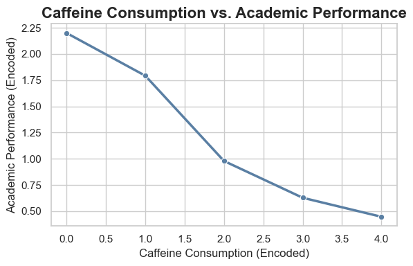

```python
sns.set(style="whitegrid")
plt.figure(figsize=(6, 4))
sns.lineplot(data=df,x='caffeine consumption_encoded',y='academic performance_encoded',errorbar=None,marker='o',linewidth=2.5,color="#5a7fa3")
plt.title("Caffeine Consumption vs. Academic Performance", fontsize=16, fontweight='bold')
plt.xlabel("Caffeine Consumption (Encoded)", fontsize=12)
plt.ylabel("Academic Performance (Encoded)", fontsize=12)
plt.tight_layout()
plt.show()
```

### 📊

*The graph shows that as caffeine consumption increases, academic performance tends to decrease.*

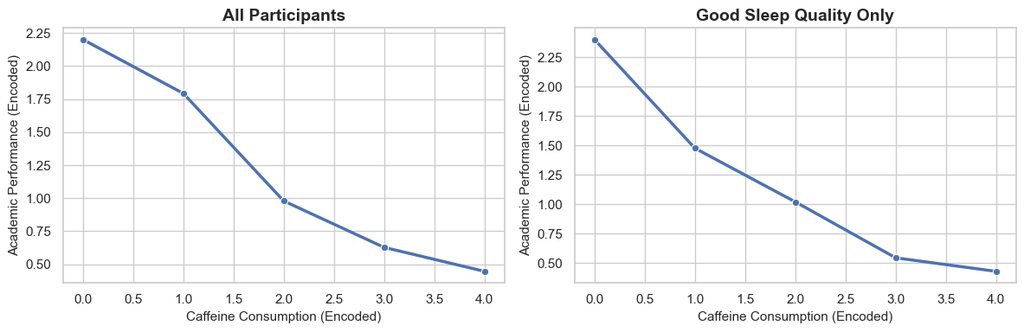

```python
sns.set(style="whitegrid")
fig, axes = plt.subplots(figsize=(12, 4), ncols=2)
sns.lineplot(data=df, x='caffeine consumption_encoded',y='academic performance_encoded',errorbar=None,marker='o',linewidth=2.5,ax=axes[0])
axes[0].set_title("All Participants", fontsize=14, fontweight='bold')
axes[0].set_xlabel("Caffeine Consumption (Encoded)", fontsize=11)
axes[0].set_ylabel("Academic Performance (Encoded)", fontsize=11)
sns.lineplot(data=df[df['sleep quality_encoded'] > 2],x='caffeine consumption_encoded',y='academic performance_encoded', errorbar=None,marker='o',linewidth=2.5,ax=axes[1])
axes[1].set_title("Good Sleep Quality Only", fontsize=14, fontweight='bold')
axes[1].set_xlabel("Caffeine Consumption (Encoded)", fontsize=11)
axes[1].set_ylabel("Academic Performance (Encoded)", fontsize=11)
plt.tight_layout()
plt.show()
```

### 📊

*Even among individuals with good sleep quality, higher caffeine consumption is still associated with lower academic performance.*

### Observation 1:

##### People who consume large amounts of caffeine are more likely to feel fatigue during the day.

##### Additionally, caffeine consumption is associated with lower academic performance.

##### These conclusions still hold even among those with good sleep quality.

[figure not shown]

### Now, let's look at the connection between physical activity and academic stress.

[figure not shown]

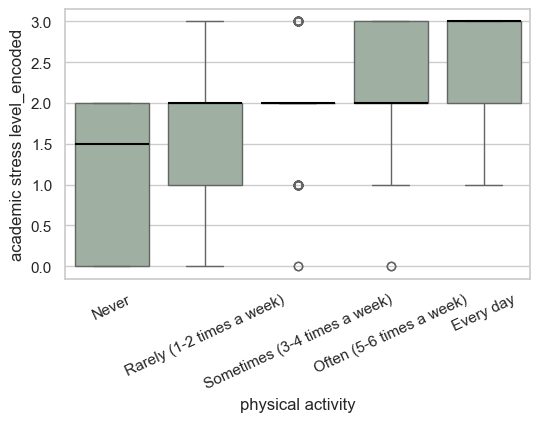

```python
plt.figure(figsize=(6, 3.5))
order = ['Never','Rarely (1-2 times a week)','Sometimes (3-4 times a week)','Often (5-6 times a week)','Every day']
sns.boxplot(data=df,x='physical activity',y ='academic stress level_encoded',order=order,medianprops=dict(color='black',linewidth=1.5),color='#9cb2a0')
plt.xticks(rotation = 25)
plt.show()
```

### 📊

*As it shown, people who reported that they do more physical activity, also reported higher stress levels.*

### But is there a connection between the academic stress and difficulty concentrating?

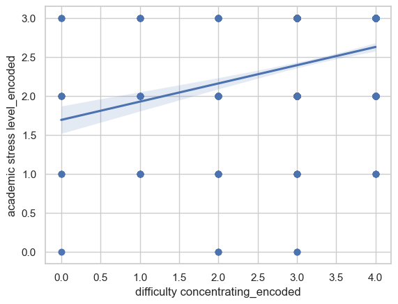

```python
sns.regplot(data = df, x = 'difficulty concentrating_encoded', y = 'academic stress level_encoded');
```

### 📊

*We can see that there is a modest connection between difficulty concentrating and academic stress (0.32).*

[figure not shown]

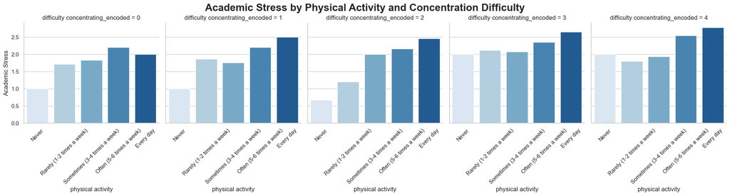

```python
sns.set(style="whitegrid")
order = ['Never','Rarely (1-2 times a week)','Sometimes (3-4 times a week)','Often (5-6 times a week)','Every day']
colors = sns.color_palette("Blues", n_colors=len(order))
color_dict = dict(zip(order, colors))
g = sns.FacetGrid(df, col='difficulty concentrating_encoded', col_wrap=5, height=4, sharey=True)
g.map_dataframe(sns.barplot,x='physical activity',y='academic stress level_encoded',hue='physical activity',order=order,errorbar=None,palette=color_dict,legend=False)
for ax in g.axes.flat:
    ax.tick_params(axis='x', rotation=45)
    ax.set_xlabel('physical activity')
    ax.set_ylabel('Academic Stress')
g.fig.subplots_adjust(top=0.85)
g.fig.suptitle("Academic Stress by Physical Activity and Concentration Difficulty", fontsize=20, fontweight='bold')
plt.show()
```

### Observation 2:

[figure not shown]

### For our last observation we wanted to check which sleep quality is the best for students.

#### Let's look at the connection between sleep quality to some of the other columns.

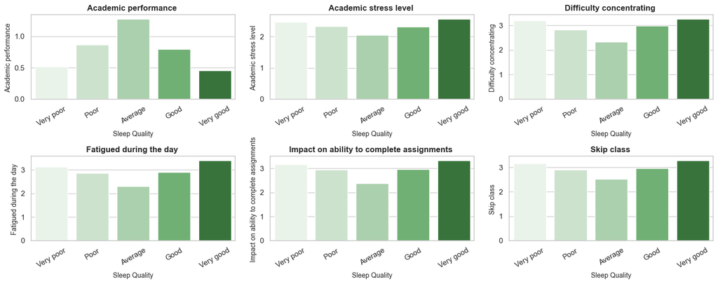

```python
fig, axes = plt.subplots(figsize=(15, 6), ncols=3, nrows = 2)
order = ['Very poor','Poor','Average','Good','Very good']
pallete =  {'Very poor': '#e8f5e9','Poor': '#c8e6c9','Average': '#a5d6a7','Good':'#66bb6a','Very good':'#2e7d32'}
sns.barplot(data = df, x = 'sleep quality',order=order,y = 'academic performance_encoded',ax = axes[0,0],hue='sleep quality',legend=False,palette = pallete,errorbar = None)
sns.barplot(data = df, x = 'sleep quality',order=order,y = 'academic stress level_encoded',ax = axes[0,1],hue='sleep quality',legend=False,palette = pallete,errorbar = None)
sns.barplot(data = df, x = 'sleep quality',order=order,y = 'difficulty concentrating_encoded',ax = axes[0,2],hue='sleep quality',legend=False,palette = pallete,errorbar = None)
sns.barplot(data = df, x = 'sleep quality',order=order,y = 'fatigued during the day_encoded',ax = axes[1,0],hue='sleep quality',legend=False,palette = pallete,errorbar = None)
sns.barplot(data = df, x = 'sleep quality',order=order,y = 'impact on ability to complete assignments_encoded',ax = axes[1,1],hue='sleep quality',legend=False,palette = pallete,errorbar = None)
sns.barplot(data = df, x = 'sleep quality',order=order,y = 'skip class_encoded',ax = axes[1,2],hue='sleep quality',legend=False,palette = pallete,errorbar = None)
for ax in axes.flat:
    ax.set_xlabel("Sleep Quality", fontsize=10)
    ax.set_ylabel(ax.get_ylabel().replace('_encoded', ' ').capitalize(), fontsize=10)
    ax.tick_params(axis='x', rotation=30)
    ax.set_title(ax.get_ylabel(), fontsize=12, fontweight='bold')
plt.tight_layout()
plt.show()
```

### Observation 3:

##### Students with average sleep quality showed the best outcomes across multiple parameters.

[figure not shown]

### Summary

במסגרת הפרויקט בחנו כיצד פרמטרים שונים של שינה – כמו איכות השינה, מספר שעות שינה ותחושת עייפות – משפיעים על הצלחה בלימודים בקרב סטודנטים. מניתוח הנתונים עלה כי ישנם קשרים מפתיעים, ביניהם קשר בין קפאין לתחושת עייפות, קשר בין פעילות גופנית לרמות סטרס, ואף התגלה כי איכות השינה שהובילה לתוצאות הטובות ביותר הייתה דווקא ממוצעת. למרות שחלק מהקשרים לא היו חד־משמעיים, נמצאו מגמות ברורות שמצביעות על חשיבותה של שינה מאוזנת ואיכותית בהשגת ביצועים אקדמיים טובים יותר. ממצאים אלו מדגישים את הצורך בטיפוח הרגלי שינה נכונים בקרב סטודנטים.